# EDA Demo: Sabermetrics

[output not shown]

A tibble is the tidyverse version of a data frame and contains additional features.

as_tibble() is preferred over as.tibble() (deprecated).

```r
dim(Batting)
```

```
[1] 105861     22
```

```r
class(Batting)
```

```
[1] "tbl_df"     "tbl"        "data.frame"
```

```r
head(Batting)
```

| playerID | yearID | stint | teamID | lgID | G | AB | R | H | X2B | X3B | HR | RBI | SB | CS | BB | SO | IBB | HBP | SH | SF | GIDP |
| --- | --- | --- | --- | --- | --- | --- | --- | --- | --- | --- | --- | --- | --- | --- | --- | --- | --- | --- | --- | --- | --- |
| abercda01 | 1871 | 1 | TRO | NA | 1 | 4 | 0 | 0 | 0 | 0 | 0 | 0 | 0 | 0 | 0 | 0 | NA | NA | NA | NA | 0 |
| addybo01 | 1871 | 1 | RC1 | NA | 25 | 118 | 30 | 32 | 6 | 0 | 0 | 13 | 8 | 1 | 4 | 0 | NA | NA | NA | NA | 0 |
| allisar01 | 1871 | 1 | CL1 | NA | 29 | 137 | 28 | 40 | 4 | 5 | 0 | 19 | 3 | 1 | 2 | 5 | NA | NA | NA | NA | 1 |
| allisdo01 | 1871 | 1 | WS3 | NA | 27 | 133 | 28 | 44 | 10 | 2 | 2 | 27 | 1 | 1 | 0 | 2 | NA | NA | NA | NA | 0 |
| ansonca01 | 1871 | 1 | RC1 | NA | 25 | 120 | 29 | 39 | 11 | 3 | 0 | 16 | 6 | 2 | 2 | 1 | NA | NA | NA | NA | 0 |
| armstbo01 | 1871 | 1 | FW1 | NA | 12 | 49 | 9 | 11 | 2 | 1 | 0 | 5 | 0 | 1 | 0 | 1 | NA | NA | NA | NA | 0 |

```r
table(Batting$lgID)
```

```
   AA    AL    FL    NA    NL    PL    UA
 1893 48654   472   738 53621   149   334
```

## dplyr verbs

### filter

```r
mlb_batting <- filter(Batting, lgID %in% c("AL", "NL"))
# filter(Batting, (lgID == "AL") | (lgID == "NL"))
nrow(Batting) - nrow(mlb_batting)
```

[output not shown]

### select

```r
sel_batting <- select(Batting, yearID, lgID, G, AB, H, BB, SO)
head(sel_batting, n = 3)
```

| yearID | lgID | G | AB | H | BB | SO |
| --- | --- | --- | --- | --- | --- | --- |
| 1871 | NA | 1 | 4 | 0 | 0 | 0 |
| 1871 | NA | 25 | 118 | 32 | 4 | 0 |
| 1871 | NA | 29 | 137 | 40 | 2 | 5 |

### arrange

```r
hr_batting <- arrange(Batting, desc(HR))
head(hr_batting)
```

| playerID | yearID | stint | teamID | lgID | G | AB | R | H | X2B | X3B | HR | RBI | SB | CS | BB | SO | IBB | HBP | SH | SF | GIDP |
| --- | --- | --- | --- | --- | --- | --- | --- | --- | --- | --- | --- | --- | --- | --- | --- | --- | --- | --- | --- | --- | --- |
| bondsba01 | 2001 | 1 | SFN | NL | 153 | 476 | 129 | 156 | 32 | 2 | 73 | 137 | 13 | 3 | 177 | 93 | 35 | 9 | 0 | 2 | 5 |
| mcgwima01 | 1998 | 1 | SLN | NL | 155 | 509 | 130 | 152 | 21 | 0 | 70 | 147 | 1 | 0 | 162 | 155 | 28 | 6 | 0 | 4 | 8 |
| sosasa01 | 1998 | 1 | CHN | NL | 159 | 643 | 134 | 198 | 20 | 0 | 66 | 158 | 18 | 9 | 73 | 171 | 14 | 1 | 0 | 5 | 20 |
| mcgwima01 | 1999 | 1 | SLN | NL | 153 | 521 | 118 | 145 | 21 | 1 | 65 | 147 | 0 | 0 | 133 | 141 | 21 | 2 | 0 | 5 | 12 |
| sosasa01 | 2001 | 1 | CHN | NL | 160 | 577 | 146 | 189 | 34 | 5 | 64 | 160 | 0 | 2 | 116 | 153 | 37 | 6 | 0 | 12 | 6 |
| sosasa01 | 1999 | 1 | CHN | NL | 162 | 625 | 114 | 180 | 24 | 2 | 63 | 141 | 7 | 8 | 78 | 171 | 8 | 3 | 0 | 6 | 17 |

### summarize

```r
summarize(Batting, max(stint), median(HR))
```

| max(stint) | median(HR) |
| --- | --- |
| 5 | 0 |

```r
filter(Batting, stint == 5)
```

| playerID | yearID | stint | teamID | lgID | G | AB | R | H | X2B | X3B | HR | RBI | SB | CS | BB | SO | IBB | HBP | SH | SF | GIDP |
| --- | --- | --- | --- | --- | --- | --- | --- | --- | --- | --- | --- | --- | --- | --- | --- | --- | --- | --- | --- | --- | --- |
| dowseto01 | 1892 | 5 | WAS | NL | 6 | 23 | 5 | 6 | 1 | 0 | 0 | 2 | 0 | NA | 0 | 3 | NA | 0 | NA | NA | NA |
| huelsfr01 | 1904 | 5 | WS1 | AL | 84 | 303 | 21 | 75 | 19 | 4 | 2 | 30 | 6 | NA | 24 | 72 | NA | 5 | 3 | NA | NA |
| chouife01 | 1914 | 5 | BRF | FL | 26 | 70 | 4 | 15 | 0 | 2 | 0 | 7 | 3 | NA | 4 | 13 | NA | 0 | 2 | NA | NA |
| drakeol01 | 2018 | 5 | MIN | AL | 19 | 0 | 0 | 0 | 0 | 0 | 0 | 0 | 0 | 0 | 0 | 0 | 0 | 0 | 0 | 0 | 0 |

### mutate

```r
new_batting <- mutate(Batting, batting_avg = H / AB, so_to_bb = SO / BB)
select(new_batting, batting_avg, so_to_bb)
```

| batting_avg | so_to_bb |
| --- | --- |
| 0.00000000 | NaN |
| 0.27118644 | 0.00000000 |
| 0.29197080 | 2.50000000 |
| 0.33082707 | Inf |
| 0.32500000 | 0.50000000 |
| 0.22448980 | Inf |
| 0.25000000 | 0.00000000 |
| 0.40127389 | 0.07692308 |
| 0.20000000 | NaN |
| 0.15116279 | NaN |

[output cut: 990 more lines]

```r
# this is annoying...
head(arrange(select(mutate(Batting, BA = H / AB), playerID, BA), desc(BA)), n = 3)
```

| playerID | BA |
| --- | --- |
| snowch01 | 1 |
| baldwki01 | 1 |
| mccafsp01 | 1 |

### pipe

```r
Batting %>%
  filter(lgID %in% c("AL", "NL"),
         AB > 300) %>%
  mutate(batting_avg = H / AB) %>%
  arrange(desc(batting_avg)) %>%
  select(playerID, yearID, batting_avg) %>%
  slice(c(1, 2, 10, 100))
```

| playerID | yearID | batting_avg |
| --- | --- | --- |
| duffyhu01 | 1894 | 0.4397032 |
| barnero01 | 1876 | 0.4285714 |
| delahed01 | 1899 | 0.4096386 |
| delahed01 | 1897 | 0.3773585 |

### group_by

```r
Batting %>%
  filter(lgID %in% c("AL", "NL")) %>%
  group_by(yearID) %>%
  summarize(hr = sum(HR), so = sum(SO), bb = sum(BB)) %>%
  arrange(desc(so)) %>%
  slice(1:5)
```

| yearID | hr | so | bb |
| --- | --- | --- | --- |
| 2018 | 5585 | 41207 | 15686 |
| 2017 | 6105 | 40104 | 15829 |
| 2016 | 5610 | 38982 | 15088 |
| 2015 | 4909 | 37446 | 14073 |
| 2014 | 4186 | 37441 | 14020 |

```r
Batting %>%
  filter(lgID %in% c("AL", "NL")) %>%
  group_by(playerID) %>%
  mutate(h_prop = H / sum(H, na.rm = TRUE)) %>%
  arrange(desc(stint)) %>%
  dplyr::select(playerID, stint, h_prop, H) %>%
  ungroup()
```

| playerID | stint | h_prop | H |
| --- | --- | --- | --- |
| dowseto01 | 5 | 0.0845070423 | 6 |
| huelsfr01 | 5 | 0.3521126761 | 75 |
| drakeol01 | 5 | NaN | 0 |
| striege01 | 4 | 0.1320754717 | 7 |
| dowseto01 | 4 | 0.1408450704 | 10 |
| kuehnbi01 | 4 | 0.0000000000 | 0 |
| ohageha01 | 4 | 0.2750000000 | 11 |
| huelsfr01 | 4 | 0.0704225352 | 15 |
| marshdo01 | 4 | 0.0377358491 | 6 |
| donahpa01 | 4 | 0.0000000000 | 0 |

[output cut: 990 more lines]

### summarize_at

```r
year_batting_summary <- Batting %>%
  filter(lgID %in% c("AL", "NL")) %>%
  group_by(yearID) %>%
  summarize_at(vars(H, HR, SO, BB, AB),
               sum, na.rm = TRUE) %>%
  mutate(batting_avg = H / AB)
year_batting_summary
```

| yearID | H | HR | SO | BB | AB | batting_avg |
| --- | --- | --- | --- | --- | --- | --- |
| 1876 | 5338 | 40 | 589 | 336 | 20121 | 0.2652950 |
| 1877 | 3705 | 24 | 726 | 345 | 13667 | 0.2710909 |
| 1878 | 3539 | 23 | 1081 | 364 | 13644 | 0.2593814 |
| 1879 | 6171 | 58 | 1843 | 508 | 24155 | 0.2554751 |
| 1880 | 5946 | 62 | 1993 | 740 | 24301 | 0.2446813 |
| 1881 | 6339 | 76 | 1784 | 1033 | 24377 | 0.2600402 |
| 1882 | 6225 | 126 | 2159 | 960 | 24769 | 0.2513222 |
| 1883 | 7611 | 124 | 2877 | 1121 | 29012 | 0.2623397 |
| 1884 | 8071 | 321 | 4335 | 1821 | 32687 | 0.2469177 |
| 1885 | 7516 | 174 | 3337 | 1845 | 31123 | 0.2414934 |

[output cut: 133 more lines]

## More examples

When were the top 3 batting averages?

```r
year_batting_summary %>%
  arrange(desc(batting_avg)) %>%
  slice(1:3)
```

| yearID | H | HR | SO | BB | AB | batting_avg |
| --- | --- | --- | --- | --- | --- | --- |
| 1894 | 17809 | 629 | 3333 | 5870 | 57577 | 0.3093075 |
| 1895 | 16827 | 488 | 3621 | 5120 | 56788 | 0.2963126 |
| 1930 | 25597 | 1565 | 7934 | 7654 | 86571 | 0.2956764 |

What is the strike out to walk ratio?

```r
year_batting_summary %>%
  mutate(so_to_bb = SO / BB) %>%
  arrange(so_to_bb) %>%
  slice(c(1, n()))
```

| yearID | H | HR | SO | BB | AB | batting_avg | so_to_bb |
| --- | --- | --- | --- | --- | --- | --- | --- |
| 1893 | 15913 | 460 | 3341 | 6143 | 56898 | 0.2796759 | 0.5438711 |
| 1879 | 6171 | 58 | 1843 | 508 | 24155 | 0.2554751 | 3.6279528 |

What were the batting averages in 1876 and 2018?

```r
year_batting_summary %>%
  select(yearID, batting_avg) %>%
  rename(Year = yearID,
         `Batting AVG` = batting_avg) %>%
  slice(c(1, n()))
```

| Year | Batting AVG |
| --- | --- |
| 1876 | 0.2652950 |
| 2018 | 0.2479569 |

```r
year_batting_summary %>%
  select(yearID, batting_avg) %>%
  rename(Year = yearID,
         `Batting AVG` = batting_avg) %>%
  arrange(desc(`Batting AVG`)) %>%
  slice(c(1:3, (n()-2):n())) %>%
  gt() %>%
  tab_header(
    title = "Best/worst MLB Seasons by AVG",
    subtitle = "Top/bottom three are presented"
  )
```

[output not shown]

## ggplot2

```r
year_batting_summary %>%
  ggplot(aes(x = yearID, y = HR)) +
  geom_point(aes(color = SO, size = BB)) +
  geom_line(color = "darkred",
            linetype = "dashed") +
  scale_color_gradient(low = "darkblue",
                       high = "darkorange") +
  labs(x = "Year", y = "Homeruns",
       color = "Strikeouts",
       size = "Walks",
       title = "The rise of MLB's three true outcomes",
       caption = "Data courtesy of Lahman") +
  theme_bw() +
  theme(legend.position = "bottom",
        plot.title = element_text(size = 15),
        axis.title = element_text(size = 10))
  # coord_cartesian() + (implicit)
  # scale_x_continuous() + (implicit)
  # scale_y_continuous() + (implicit)
  # scale_y_continuous(breaks = seq(0, 6000, by = 1000)) +
  # scale_x_reverse() +
  # scale_y_log10() +
  # geom_smooth() (smoothing regression)
```

[output not shown]

### pivot the data

pivot_longer - gathers information spread out across variables, increase nrow() but decrease ncol()

pivot_wider - spreads information out from observations, decrease nrow() but increase ncol()

```r
year_batting_summary %>%
  select(yearID, HR, SO, BB) %>%
  rename(HRs = HR, Strikeouts = SO, Walks = BB) %>%
  pivot_longer(HRs:Walks,
               names_to = "stat",
               values_to = "value") %>%
  ggplot(aes(x = yearID, y = value)) +
  geom_line(color = "darkblue") +
  geom_point(color = "darkblue") +
  facet_wrap(~ stat, scales = "free_y", ncol = 1) +
  labs(x = "Year", y = "Total of statistic",
       title = "The rise of MLB's three true outcomes",
       caption = "Data courtesy of Lahman") +
  theme_bw() +
  theme(strip.background = element_blank())
```

[output not shown]

### univariate data

#### 1D discrete

```r
trout_batted_balls <- read_csv("http://www.stat.cmu.edu/cmsac/sure/materials/data/xy_examples/trout_2019_batted_balls.csv")
```

### 1D continuous

For continuous variables, we're interested in the shape, center, and spread of the distribution.

```r
# Boxplot
trout_batted_balls %>%
  ggplot(aes(y = exit_velocity)) +
  geom_boxplot(aes(x = "")) +
  theme_bw() +
  coord_flip() +
  theme(axis.title.y = element_blank(),
        axis.ticks.y = element_blank())
```

[output not shown]

Pros: displays outliers, percentiles, spread, skew Cons: can't tell how many modes

```r
# Histogram
trout_batted_balls %>%
  ggplot(aes(x = exit_velocity)) +
  geom_histogram(bins = 100) +
  theme_bw()
```

[output not shown]

Still a summary.

```r
library(ggbeeswarm)
# Beeswarm plot (jittered dotplot)
trout_batted_balls %>%
  ggplot(aes(y = exit_velocity)) +
  geom_beeswarm(aes(x = ""),
                cex = 3) +
  theme_bw() +
  coord_flip()
```

[output not shown]

Shows all data points (good for small datasets).

```r
# Violin plot
trout_batted_balls %>%
  ggplot(aes(x = "", y = exit_velocity)) +
  geom_violin() +
  geom_beeswarm(cex = 3) +
  geom_boxplot(width = 0.2,
               alpha = .6) +
  theme_bw() +
  coord_flip()
```

[output not shown]

Violin plots are nice because you can also see the distribution shape.

```r
# Empirical (sample) CDF
trout_batted_balls %>%
  ggplot(aes(x = exit_velocity)) +
  stat_ecdf() +
  theme_bw()
```

[output not shown]

Pros: ECDF displays all information in data (except for order), converges in distribution, easy to interpret Cons: Not very popular

```r
# Rug plot + histogram
trout_batted_balls %>%
  ggplot(aes(x = exit_velocity)) +
  geom_histogram() +
  geom_rug(alpha = 0.3) +
  theme_bw()

# Rug + scatterplot
trout_batted_balls %>%
  ggplot(aes(x = exit_velocity,
             y = launch_angle)) +
  geom_point() +
  geom_rug(alpha = 0.3) +
  theme_bw()
```

[output not shown]

Useful when added to other visualizations, e.g. ECDF

### bivariate data

#### 2D categorical

```r
trout_batted_balls %>%
  ggplot(aes(x = batted_ball_type,
             fill = pitch_type)) +
  geom_bar(position = "dodge") +
  theme_bw()
```

[output not shown]

Stacked bar charts emphasize the marginal distribution.

Side-by-side bar charts emphasize the conditional distribution.

```r
# contingency table - frequency
trout_batted_balls %>%
  group_by(batted_ball_type, pitch_type) %>%
  summarize(joint_freq = n()) %>%
  pivot_wider(names_from = batted_ball_type,
              value_from = joint_freq)

# contingency table - probability
trout_batted_balls %>%
  group_by(batted_ball_type, pitch_type) %>%
  summarize(joint_prob = n() / nrow(trout_batted_balls)) %>%
  pivot_wider(names_from = batted_ball_type,
              values_from = joint_prob) %>%
  gt()
```

[output not shown]

Marginal distribution - row/column sums Conditional distribution - individual cell/marginal Two variables X, Y are independent iff P(x)P(y) = P(x, y).

```r
# visualizing independence
mosaic(~ pitch_type + batted_ball_type,
       data = trout_batted_balls)
```

[output not shown]

Spine chart of spine charts height = marginal distribution of pitch_type width = conditional distribution of batted_ball_type | pitch_type area = joint distribution

```r
# side-by-side violins
trout_batted_balls %>%
  ggplot(aes(x = pitch_type,
             y = exit_velocity)) +
  geom_violin() +
  geom_boxplot(width = .4) +
  theme_bw()
```

[output not shown]

```r
# ecdf
trout_batted_balls %>%
  ggplot(aes(x = exit_velocity,
             color = pitch_type)) +
  stat_ecdf() +
  theme_bw() +
  theme(legend.position = "bottom")
```

[output not shown]

```r
# stacked histogram
trout_batted_balls %>%
  ggplot(aes(x = exit_velocity,
             fill = pitch_type)) +
  geom_histogram() +
  theme_bw() +
  theme(legend.position = "bottom")
```

[output not shown]

```r
trout_batted_balls %>%
  ggplot(aes(x = exit_velocity,
             color = pitch_type)) +
  geom_freqpoly() +
  theme_bw() +
  theme(legend.position = "bottom")
```

[output not shown]

```r
trout_batted_balls %>%
  ggplot(aes(x = exit_velocity)) +
  geom_histogram() +
  theme_bw() +
  facet_wrap(~ pitch_type, ncol = 2)
```

[output not shown]

```r
trout_batted_balls %>%
  ggplot(aes(x = exit_velocity)) +
  geom_histogram() +
  theme_bw() +
  facet_grid(pitch_type ~., margins = TRUE)
```

[output not shown]

### multivariable data

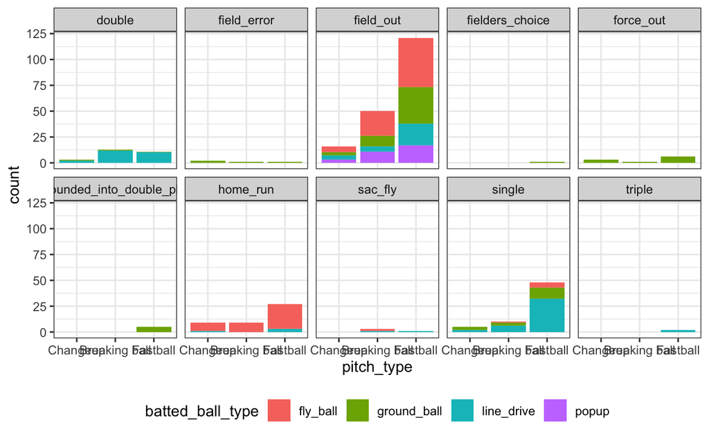